# 探索性数据分析——来自拍拍贷的业务数据

背景介绍： 拍拍贷是一家中国在线P2P金融公司，为千万互联网用户提供借贷金融服务。 本项目拟通过拍拍贷真实的业务数据，分析贷款的去向和影响借贷利率的因素。

0.加载最终使用的所有组件

1.探索数据集

1.1查看数据集的整体情况

```r
dim(lc)
```

```
## [1] 328553     21
```

```r
str(lc)
```

```
## 'data.frame':    328553 obs. of  21 variables:
##  $ ListingId       : int  126541 133291 142421 149711 152141 162641 171191 175451 182261 193831 ...
##  $ 借款金额        : int  18000 9453 27000 25000 20000 20000 3940 20000 25000 10475 ...
##  $ 借款期限        : int  12 12 24 12 6 12 6 12 12 6 ...
##  $ 借款利率        : num  18 20 20 18 16 14 18 18 16 18 ...
##  $ 借款成功日期    : Factor w/ 756 levels "2015-01-01","2015-01-02",..: 119 70 477 84 22 79 172 439 75 100 ...
##  $ 初始评级        : Factor w/ 6 levels "A","B","C","D",..: 3 4 5 3 3 1 5 2 2 3 ...
##  $ 借款类型        : Factor w/ 4 levels "APP闪电","电商",..: 4 4 3 4 2 3 2 3 4 2 ...
##  $ 是否首标        : Factor w/ 2 levels "否","是": 1 1 1 1 1 1 1 1 1 1 ...
##  $ 年龄            : int  35 34 41 34 24 36 27 32 33 25 ...
##  $ 性别            : Factor w/ 2 levels "男","女": 1 1 1 1 1 1 2 1 2 1 ...
##  $ 手机认证        : Factor w/ 2 levels "成功认证","未成功认证": 1 2 1 1 1 1 1 1 1 1 ...
##  $ 户口认证        : Factor w/ 2 levels "成功认证","未成功认证": 2 1 2 1 1 1 1 1 2 1 ...
##  $ 视频认证        : Factor w/ 2 levels "成功认证","未成功认证": 1 2 2 1 1 1 1 1 1 1 ...
##  $ 学历认证        : Factor w/ 2 levels "成功认证","未成功认证": 2 2 2 2 2 2 2 2 2 2 ...
##  $ 征信认证        : Factor w/ 2 levels "成功认证","未成功认证": 2 2 2 2 2 2 2 2 2 2 ...
##  $ 淘宝认证        : Factor w/ 2 levels "成功认证","未成功认证": 2 2 2 2 2 2 2 2 2 2 ...
##  $ 历史成功借款次数: int  11 4 5 6 13 7 15 7 7 9 ...
##  $ 历史成功借款金额: num  40326 14500 21894 36190 77945 ...
##  $ 总待还本金      : num  8713 7891 11726 9703 0 ...
##  $ 历史正常还款期数: int  57 13 25 41 118 56 75 52 41 49 ...
##  $ 历史逾期还款期数: int  16 1 3 1 14 0 8 0 2 4 ...
```

```r
summary(lc)
```

```
##    ListingId           借款金额         借款期限        借款利率
##  Min.   :  126541   Min.   :   100   Min.   : 1.00   Min.   : 6.5
##  1st Qu.:11908871   1st Qu.:  2033   1st Qu.: 6.00   1st Qu.:20.0
##  Median :19523251   Median :  3397   Median :12.00   Median :20.0
##  Mean   :19079479   Mean   :  4424   Mean   :10.21   Mean   :20.6
##  3rd Qu.:26298621   3rd Qu.:  5230   3rd Qu.:12.00   3rd Qu.:22.0
##  Max.   :32819531   Max.   :500000   Max.   :24.00   Max.   :24.0
##
##      借款成功日期    初始评级      借款类型      是否首标
##  2017-01-25:  3558   A: 10284   APP闪电:112079   否:241090
##  2017-01-20:  3063   B: 33188   电商   :  1069   是: 87463
##  2016-12-14:  2266   C:131705   普通   :118103
##  2016-12-02:  2033   D:134860   其他   : 97302
##  2017-01-09:  1859   E: 17027
##  2017-01-04:  1806   F:  1489
##  (Other)   :313968
##       年龄       性别              手机认证            户口认证
##  Min.   :17.00   男:221946   成功认证  :123007   成功认证  : 10105
##  1st Qu.:24.00   女:106607   未成功认证:205546   未成功认证:318448
##  Median :28.00
##  Mean   :29.14
##  3rd Qu.:33.00
##  Max.   :56.00
##
##        视频认证            学历认证            征信认证
##  成功认证  : 18501   成功认证  :114124   成功认证  :  9606
##  未成功认证:310052   未成功认证:214429   未成功认证:318947
##
##
##
##
##
##        淘宝认证      历史成功借款次数  历史成功借款金额    总待还本金
##  成功认证  :  1152   Min.   :  0.000   Min.   :      0   Min.   :      0
##  未成功认证:327401   1st Qu.:  0.000   1st Qu.:      0   1st Qu.:      0
##                      Median :  2.000   Median :   5000   Median :   2542
##                      Mean   :  2.323   Mean   :   8786   Mean   :   3722
##                      3rd Qu.:  3.000   3rd Qu.:  10355   3rd Qu.:   5447
##                      Max.   :649.000   Max.   :7405926   Max.   :1172653
##
##  历史正常还款期数   历史逾期还款期数
##  Min.   :   0.000   Min.   : 0.0000
##  1st Qu.:   0.000   1st Qu.: 0.0000
##  Median :   5.000   Median : 0.0000
##  Mean   :   9.948   Mean   : 0.4233
##  3rd Qu.:  13.000   3rd Qu.: 0.0000
##  Max.   :2507.000   Max.   :60.0000
##
```

LC数据集一共有328553个对象，21个变量。

1.2 查看数据集变量类型  
1. ListingId：列表序号，为列表的唯一键  
2. 借款金额：列表成交总金额  
3. 借款期限：总的期数（按月计）  
4. 借款利率：年化利率（百分数）  
5. 借款成功日期：列表成交的日期。都在2015年1月1日以后  
6. 初始评级：列表成交时的信用评级。AAA为安全标，AA为赔标，A-F为信用等级  
7. 借款类型：分为“应收安全标”，“电商”，“APP闪电”，“普通”和“其他”  
8. 是否首标：该标是否为借款人首标  
9. 年龄：借款人再该列表借款成功时的年龄  
10. 性别：该列表借款人性别  
11. 手机认证：该列表借款人手机实名认证是否成功  
12. 户口认证：该列表借款人户口认证是否成功  
13. 视频认证：该列表借款人视频认证是否成功  
14. 学历认证：该列表借款人学历认证是否成功，成功则表示有大专及以上学历  
15. 征信认证：该列表借款人征信认证是否成功，成功则表示有人行征信报告  
16. 淘宝认证：该列表借款人淘宝认证是否成功，成功则表示为淘宝店主  
17. 历史成功借款次数：借款人在该列表成交之前的借款成功金额  
18. 历史成功借款金额：借款人在该列表成交之前的借款成功金额  
19. 总待还本金：借款人在该列表成交之前待还本金金额  
20. 历史正常还款期数：借款人在该列表成交之前的按期还款期数  
21. 历史逾期还款期数：借款人在该列表成交之前的预期还款期数

2. 数据处理

2.1 日期处理

```r
lc <- separate(lc, 借款成功日期, c('year','month','day'), sep='-', remove=FALSE)
```

将借款成功日期分开为year, month, day便于后面的分析

2.2 认证评分（1表示认证成功，0表示未认证成功）

```r
lc$认证分数 <- (lc$手机认证=='成功认证') +
  (lc$户口认证=='成功认证') +
  (lc$视频认证=='成功认证') +
  (lc$学历认证=='成功认证') +
  (lc$征信认证=='成功认证') +
  (lc$淘宝认证=='成功认证')
```

2.3 客户评级(A为最高等级，F为最低等级)

```r
lc$初始评级 <- factor(lc$初始评级,levels=c('F','E','D','C','B','A'),ordered=T)
```

3. 单变量分析

3.1.1 借款金额分析

```r
summary(lc$借款金额)
```

```
##    Min. 1st Qu.  Median    Mean 3rd Qu.    Max.
##     100    2033    3397    4424    5230  500000
```

```r
quantile(lc$借款金额, 0.95)
```

```
##  95%
## 9000
```

可以看到最小借款金额为100元，最大借款金额为500000元，中位数为3397元， 均值为4424元，75%的借款金额在5230以下，95%的人借款金额在9000以下

3.1.2 这里绘制借款金额的直方图，横坐标设定范围为0-10000元

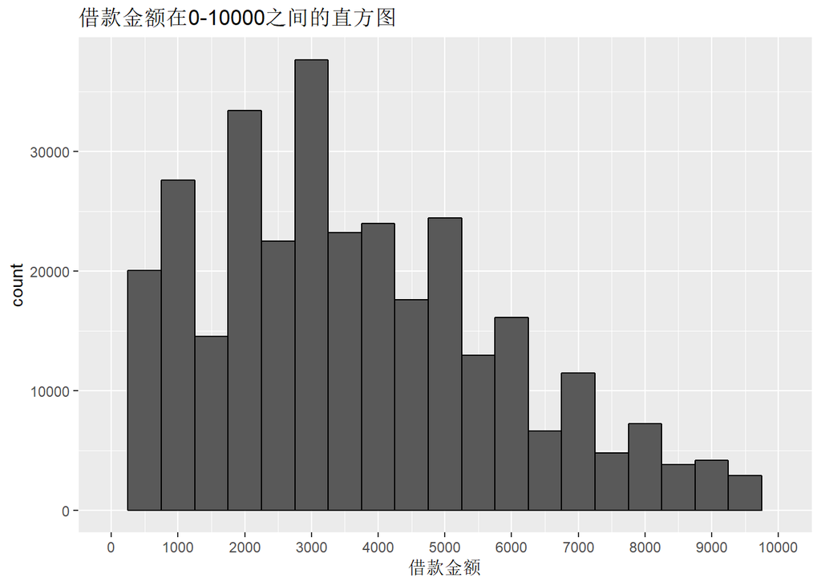

```r
ggplot(aes(x=借款金额),data=lc) +
  geom_histogram(color='black', binwidth = 500)+
  scale_x_continuous(limits=c(0,10000), breaks=seq(0,10000,1000)) +
  ggtitle('借款金额在0-10000之间的直方图')
```

可以看到基本借款数最多的借款金额在3000元左右，说明借款数量普遍偏低，推测借款 人员普遍收入较低或为学生群体

3.1.3 对借款金额进行分区间

```r
lc$借款金额区间 <- cut(lc$借款金额,c(0,1000,3000,5000,10000,500000))
levels(lc$借款金额区间)
```

```
## [1] "(0,1e+03]"     "(1e+03,3e+03]" "(3e+03,5e+03]" "(5e+03,1e+04]"
## [5] "(1e+04,5e+05]"
```

3.2.1 借款期限分析

```r
summary(lc$借款期限)
```

```
##    Min. 1st Qu.  Median    Mean 3rd Qu.    Max.
##    1.00    6.00   12.00   10.21   12.00   24.00
```

```r
table(lc$借款期限)
```

```
##
##      1      2      3      4      5      6      7      8      9     10
##     42    802   1993     94     85  84486   1239   1852  10769   5472
##     11     12     15     17     18     20     21     24
##   5351 215330     31      1    367      1      2    636
```

3.2.2 绘制借款期限的直方图

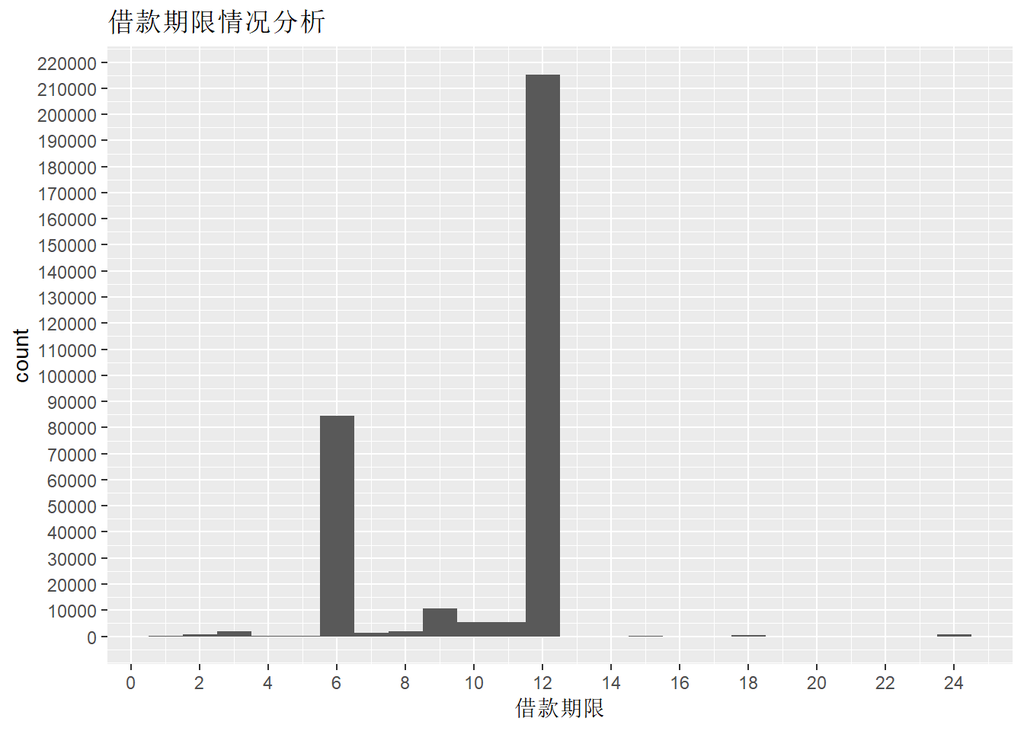

```r
ggplot(aes(x=借款期限),data=lc) + geom_histogram(binwidth = 1)+
  scale_x_continuous(breaks=seq(0,25,2)) +
  scale_y_continuous(breaks=seq(0,250000,10000)) +
  ggtitle('借款期限情况分析')
```

从图中可以看到借款期限最多的为12期达到了210000人左右，其次是6期达到了85000人 左右，然后是9期的在10000人左右，其余的借款期数都少于10000人，超过12期的人数特 别少，说明整体来说借款期限都不是很长。

3.3.1 借款利率情况的分析

```r
summary(lc$借款利率)
```

```
##    Min. 1st Qu.  Median    Mean 3rd Qu.    Max.
##     6.5    20.0    20.0    20.6    22.0    24.0
```

```r
table(lc$借款利率)
```

```
##
##    6.5      8    8.5      9     10   10.5     11     12     13     14
##      1      1      1     12      9      1      7    589     48    622
##   14.4   14.6     15   15.1   15.8     16     17     18   18.2   18.3
##      1      1    201      6      2  10558     36  38777      1      1
##     19     20   20.2   20.5     21   21.4     22   22.2  22.24   22.3
##     60 126330      1      2    149      1 137899      2      1      1
##   22.4   22.5  22.88     23     24
##      6      1      1   1147  12077
```

从表中可以得出：利率范围在6.5%到24%之间

3.3.2 利率分布情况直方图

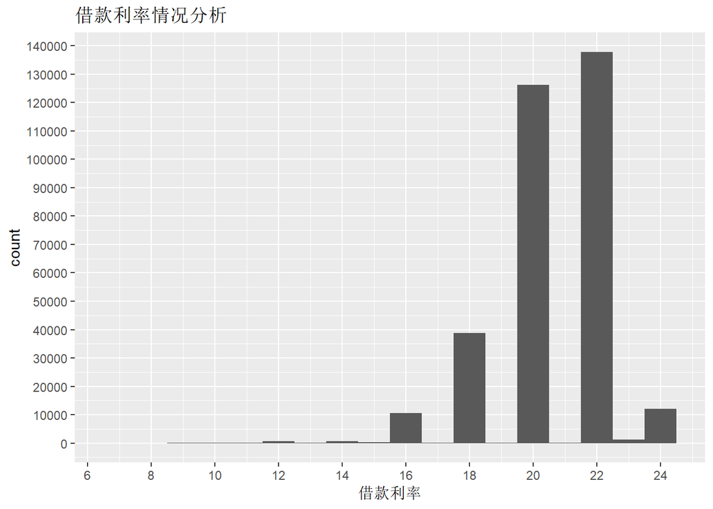

```r
ggplot(aes(x=借款利率),data=lc) + geom_histogram(binwidth = 1)+
  scale_x_continuous(breaks=seq(0,25,2)) +
  scale_y_continuous(breaks=seq(0,250000,10000)) +
  ggtitle('借款利率情况分析')
```

从图中可以得出：借款利率最高为24%，但人数不是特别多，借款利率为22%的人最多， 其次是20%和18%，其他借款利率的人数都比较少

3.4.1 借款人年龄分布的分析

```r
summary(lc$年龄)
```

```
##    Min. 1st Qu.  Median    Mean 3rd Qu.    Max.
##   17.00   24.00   28.00   29.14   33.00   56.00
```

可以看到借款人最小为17岁，最大为56岁，借款人平均年龄在29岁左右

3.4.2 绘制借款人年龄直方图

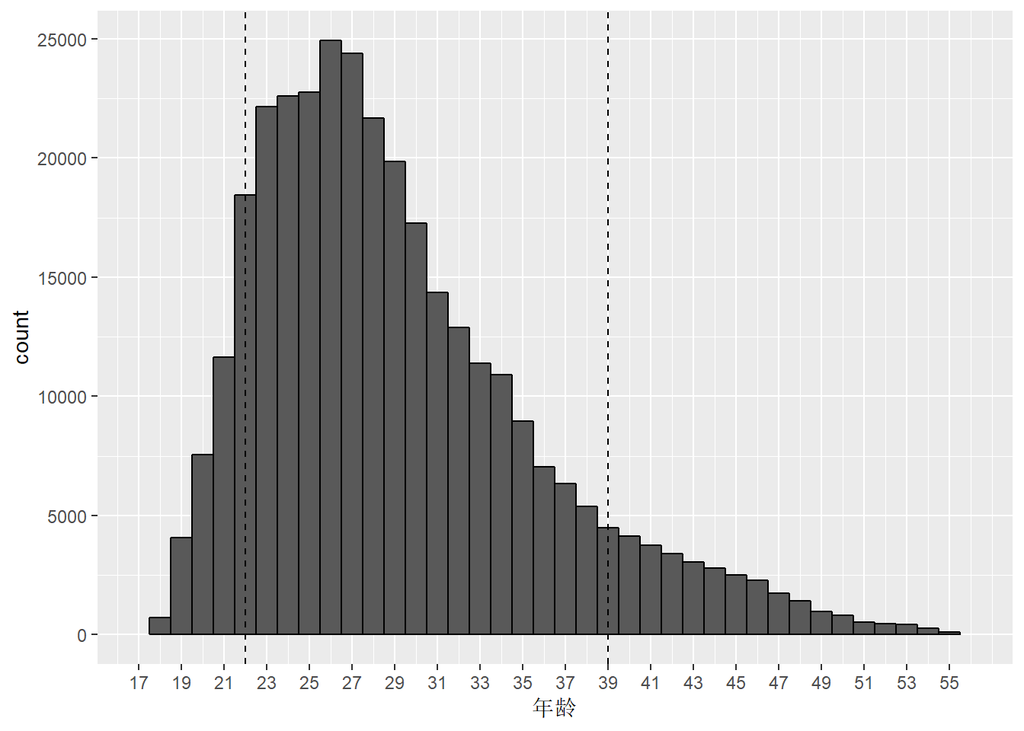

```r
ggplot(aes(x=年龄),data=lc) + geom_histogram(binwidth = 1,color='black') +
  scale_x_continuous(limits=c(17,56),breaks=seq(17,56,2)) +
  geom_vline(xintercept = quantile(lc$年龄,0.1), linetype='dashed') +
  geom_vline(xintercept = quantile(lc$年龄,0.9),linetype='dashed')
```

从图中可以看到80%的借款人年龄在22到39岁之间

3.4.3 借款人年龄区间划分

```r
lc$年龄区间 <- cut(lc$年龄, c(15,20,25,30,35,40,45,50,56))
```

3.5.1 借款人性别分析

```r
table(lc$性别)
```

```
##
##     男     女
## 221946 106607
```

3.5.2 绘制借款人性别直方图

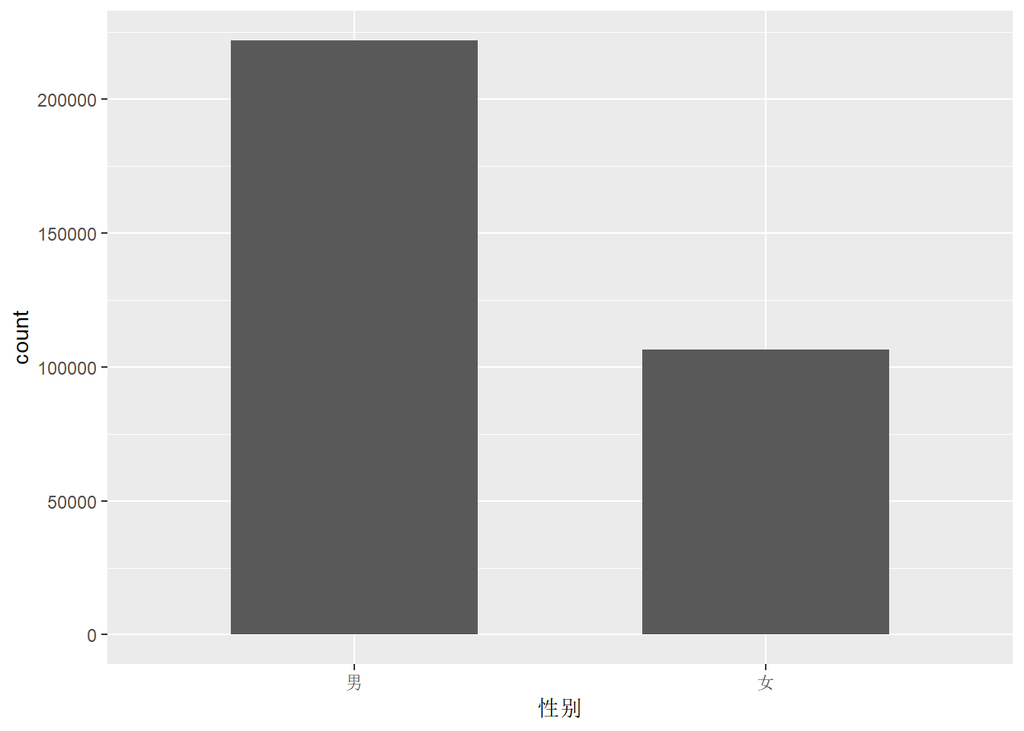

```r
ggplot(aes(x=性别), data=lc) + geom_bar(width=0.6)
```

3.6.1 借款成功日期分析

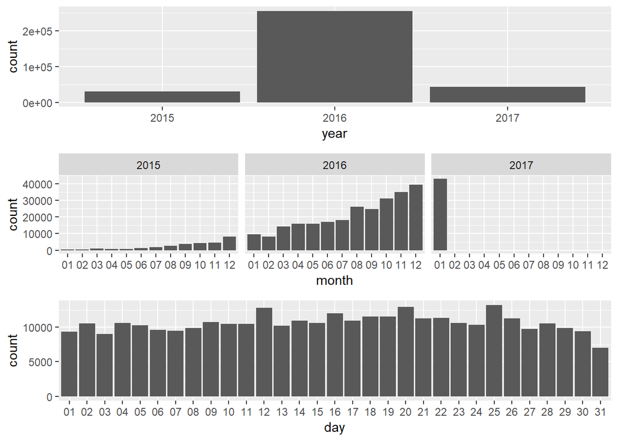

```r
year_lc <- ggplot(aes(x=year), data=lc) + geom_bar()
month_lc <- ggplot(aes(x=month), data=lc) + geom_bar() + facet_wrap(~year)
day_lc <- ggplot(aes(x=day), data=lc) + geom_bar()
grid.arrange(year_lc,month_lc,day_lc,ncol=1)
```

3.7.1 对认证方式进行分析

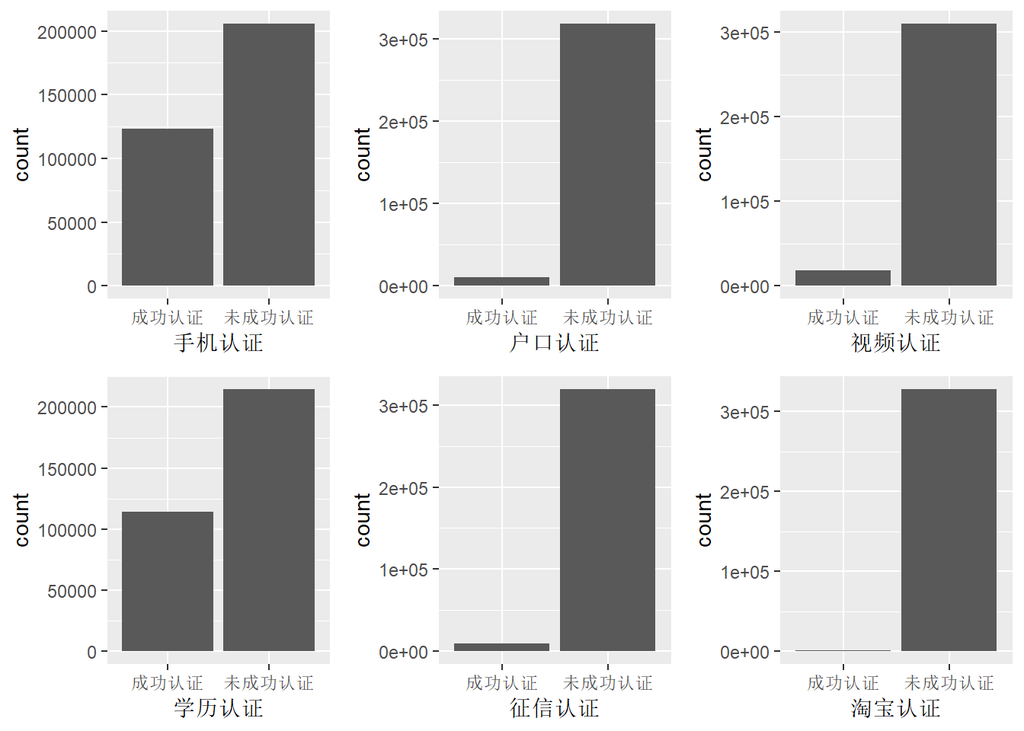

```r
phone_lc <- ggplot(aes(x=手机认证),data=lc) + geom_bar()
id_lc <- ggplot(aes(x=户口认证),data=lc) + geom_bar()
video_lc <- ggplot(aes(x=视频认证),data=lc) + geom_bar()
edu_lc <- ggplot(aes(x=学历认证),data=lc) + geom_bar()
credit_lc <- ggplot(aes(x=征信认证),data=lc) + geom_bar()
biz_lc <- ggplot(aes(x=淘宝认证),data=lc) + geom_bar()
grid.arrange(phone_lc, id_lc, video_lc, edu_lc, credit_lc,biz_lc,ncol=3)
```

3.8.1 认证分数分析

```r
summary(lc$认证分数)
```

```
##    Min. 1st Qu.  Median    Mean 3rd Qu.    Max.
##  0.0000  0.0000  1.0000  0.8416  1.0000  6.0000
```

3.8.2 绘制认证分数直方图

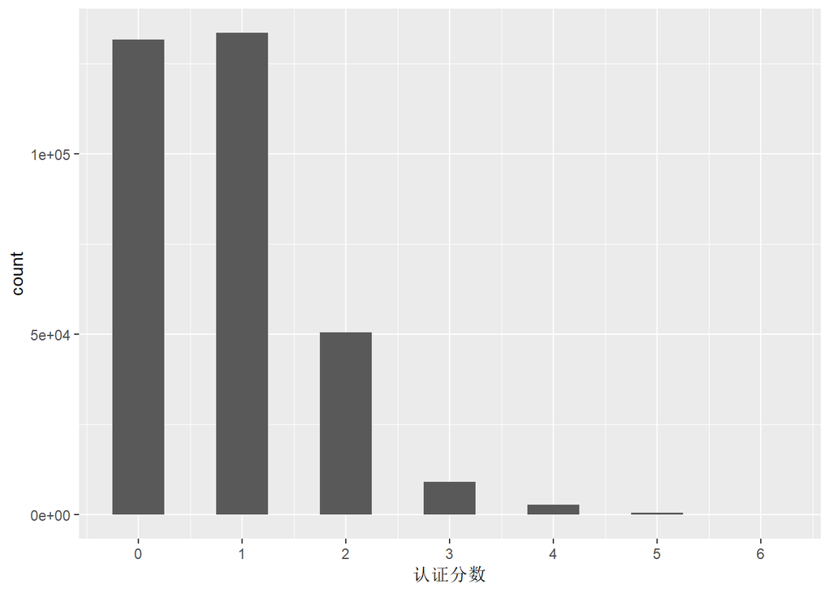

```r
ggplot(aes(x=认证分数),data=lc) + geom_histogram(binwidth = 0.5) +
  scale_x_continuous(breaks=seq(0,6,1))
```

```r
table(lc$认证分数)
```

```
##
##      0      1      2      3      4      5      6
## 131776 133598  50622   9143   2859    542     13
```

从上图和上表可以看出，大部分都认证少于等于1项，认证多项的人很少。

3.9.1 初始评级分析

```r
table(lc$初始评级)
```

```
##
##      F      E      D      C      B      A
##   1489  17027 134860 131705  33188  10284
```

3.9.2 绘制初始评级直方图

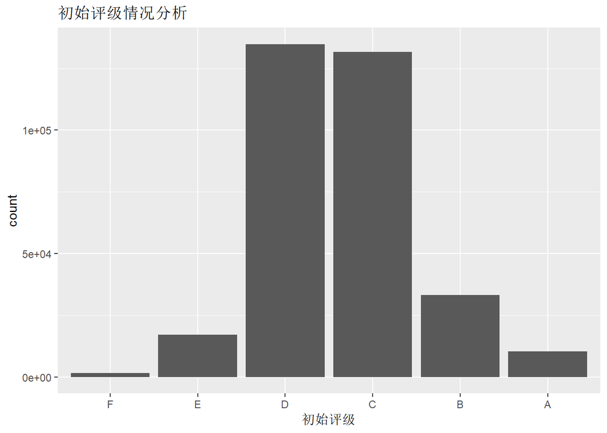

```r
ggplot(aes(x=初始评级),data=lc) +
  geom_bar() +
  ggtitle('初始评级情况分析')
```

从图中可以得出：初始评级在D/C的占大多数，其余的评级的人数都很少

3.10.1 借款类型情况分析

```r
table(lc$借款类型)
```

```
##
## APP闪电    电商    普通    其他
##  112079    1069  118103   97302
```

从表中可以看出：除了电商外，其他类型借款都比较多，在双变量和多变量分析时可以 单独拿出电商类借款分析

3.11.1 是否首标情况分析

```r
table(lc$是否首标)
```

```
##
##     否     是
## 241090  87463
```

从表中可以得知：首标的借款在1/4左右，非首标的在3/4左右，在后续分析中可以将是 否首标拆开分析，分析是否首标在借款方面有无差异

4. 双变量分析

4.1.1 借款金额与年龄之间的关系

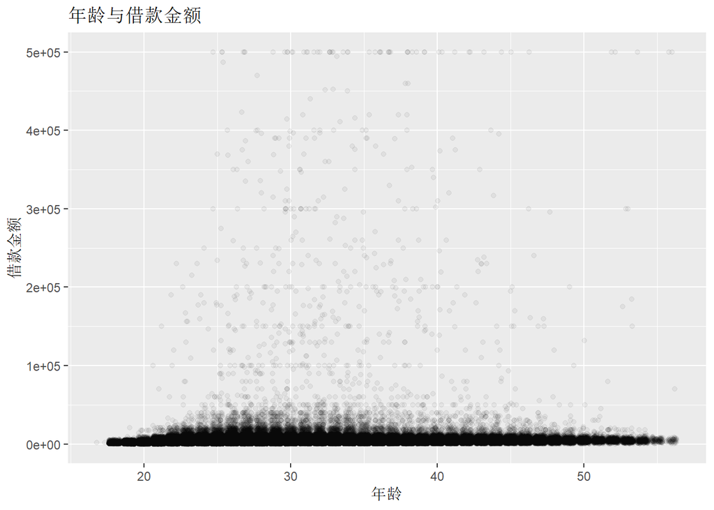

```r
ggplot(aes(x=年龄,y=借款金额), data= lc) +
  geom_point(position='jitter',alpha=1/20) +
  ggtitle('年龄与借款金额')
```

根据之前单变量分析借款金额时发现，绝大多数人的借款金额都在10000元以下，但从上 图可以看到有部分借款金额特别大，这里将这两部分拆开分析

4.1.2 将借款金额比较大的和比较小的拆开分析

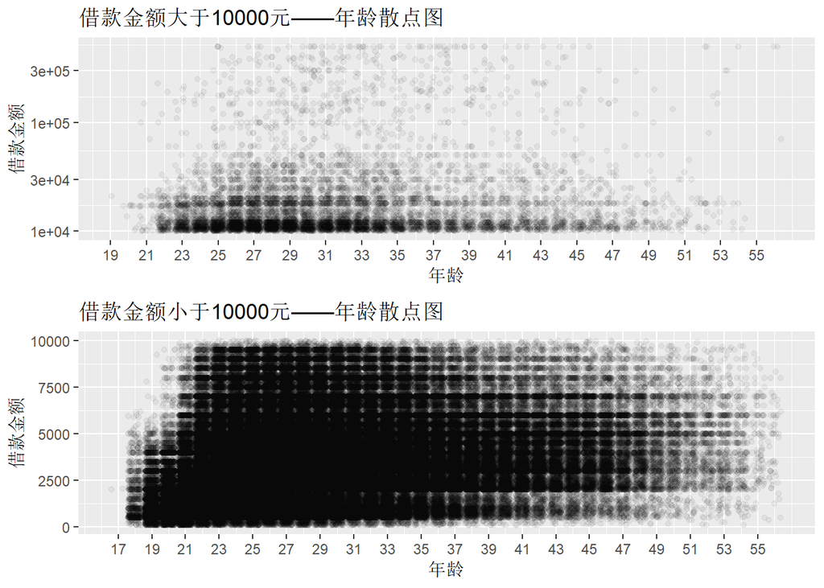

```r
beyond10000 <- subset(lc, 借款金额>10000)
within10000 <- subset(lc, 借款金额<10000)
beyond10000_plot <- ggplot(aes(x=年龄,y=借款金额), data= beyond10000) +
  geom_point(position='jitter',alpha=1/20) +
  ggtitle('借款金额大于10000元——年龄散点图') +
  scale_x_continuous(breaks=seq(17,56,2)) +
  scale_y_log10()
within10000_plot <- ggplot(aes(x=年龄, y=借款金额),data=within10000) +
  geom_point(position='jitter',alpha=1/20) +
  ggtitle('借款金额小于10000元——年龄散点图') +
  scale_x_continuous(breaks=seq(17,56,2))
grid.arrange(beyond10000_plot,within10000_plot)
```

4.2 年龄区间与借款金额的关系

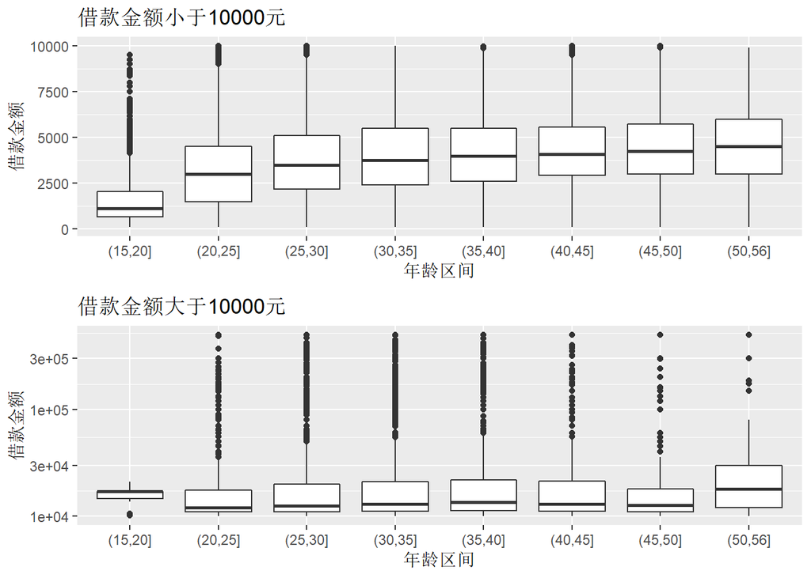

```r
p2_2.1 <- ggplot(aes(x=年龄区间,y=借款金额),data=within10000) +
  geom_boxplot() + ggtitle('借款金额小于10000元')

p2_2.2 <- ggplot(aes(x=年龄区间,y=借款金额),data=beyond10000) +
  geom_boxplot() + scale_y_log10() +
  ggtitle('借款金额大于10000元')

grid.arrange(p2_2.1,p2_2.2)
```

结论： 在较小的借款金额(小于10000元)的范围内，15-25之间增长幅度比较大，从25岁以后借 款金额差别不是很大; 在较大的借款金额中，通过箱型图可以看出有一些借款金额异常大

4.1.3 不同年龄段的借款金额汇总分布情况

按年龄进行分组汇总借款金额

```r
library(dplyr)
age_group <- group_by(lc,年龄)
lc.by_age <- summarise(age_group,
            mean_jine = mean(as.numeric(借款金额)),
            sum_jine=sum(as.numeric(借款金额)),n = n())
head(lc.by_age)
```

```
## # A tibble: 6 x 4
##    年龄 mean_jine sum_jine     n
##   <int>     <dbl>    <dbl> <int>
## 1    17     2022.     4045     2
## 2    18     1753.  1272615   726
## 3    19     1488.  6051040  4067
## 4    20     1669. 12607826  7553
## 5    21     2179. 25359042 11640
## 6    22     3004. 55452312 18457
```

```
## No summary function supplied, defaulting to `mean_se()
## No summary function supplied, defaulting to `mean_se()
```

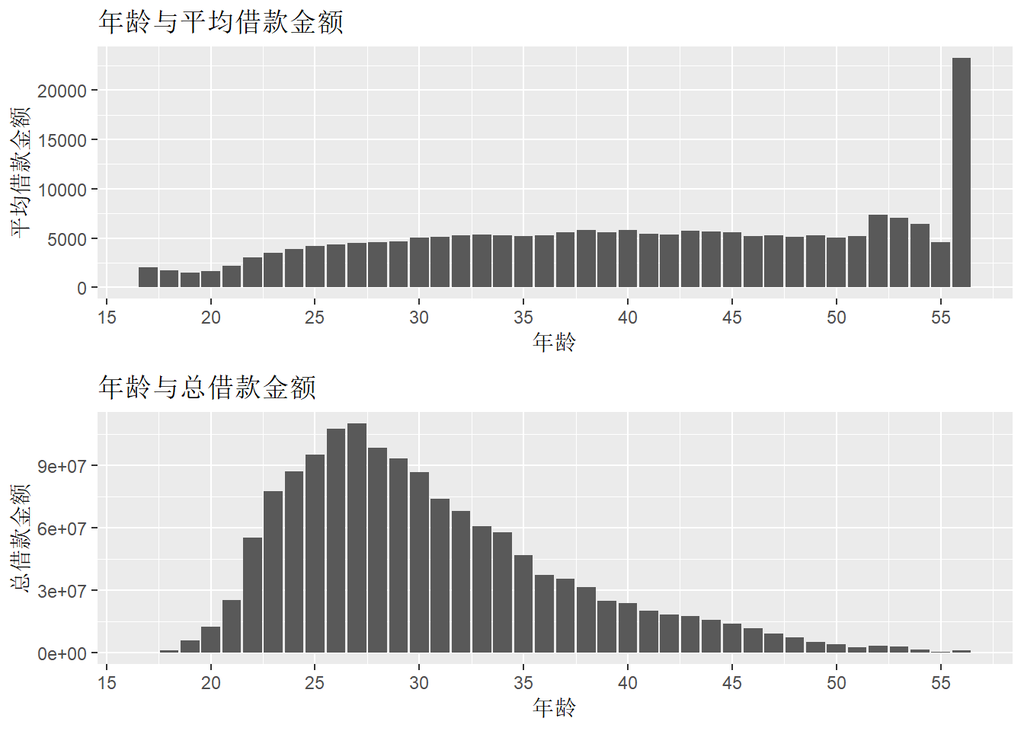

```r
p2_1.1 <- ggplot(aes(x=年龄,y=mean_jine),data=lc.by_age) +
  geom_bar(stat='summary') +
  scale_x_continuous(breaks=seq(15,60,5)) +
  ylab('平均借款金额') +
  ggtitle('年龄与平均借款金额')
p2_1.2 <- ggplot(aes(x=年龄,y=sum_jine),data=lc.by_age) +
  geom_bar(stat='summary') +
  scale_x_continuous(breaks=seq(15,60,5)) +
  ylab('总借款金额') +
  ggtitle('年龄与总借款金额')
grid.arrange(p2_1.1,p2_1.2,ncol=1)
```

结论：从平均借款金额上看，随着年龄的增长平均借款金额有所增长，但幅度不算很大。 但从总借款金额上看，在20-40之间借款总额占据了大多数，反映了在20-40岁之间的用户占 据大多数，这与前面单变量分析用户年龄的情况相符合。

4.2.1 性别与借款金额之间的关系

按性别进行分组

```r
gender_group <- group_by(lc,性别)
lc.by_gender <- summarise(gender_group,
                          mean_jine = mean(as.numeric(借款金额)),
                          sum_jine = sum(as.numeric(借款金额)))
```

4.2.2 按性别进行图形绘制

```
## No summary function supplied, defaulting to `mean_se()
## No summary function supplied, defaulting to `mean_se()
```

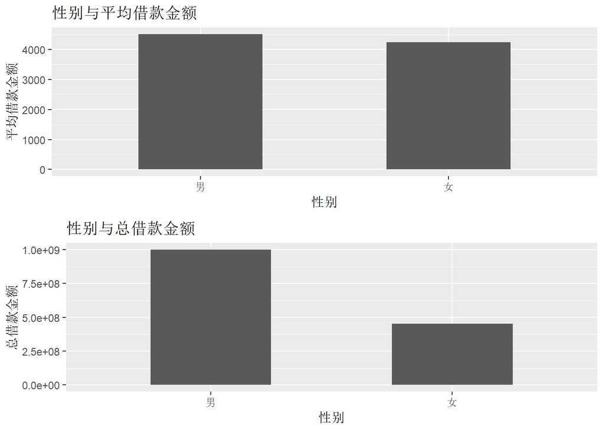

```r
p2_2.1 = ggplot(aes(x=性别,y=mean_jine),data=lc.by_gender) +
  geom_bar(stat='summary',width = 0.5) + ylab('平均借款金额') +
  ggtitle('性别与平均借款金额')
p2_2.2 = ggplot(aes(x=性别,y=sum_jine),data=lc.by_gender) +
  geom_bar(stat='summary',width = 0.5)+ylab('总借款金额') +
  ggtitle('性别与总借款金额')
grid.arrange(p2_2.1,p2_2.2,ncol=1)
```

结论：对男女不同性别来说，平均借款金额差异不是很大，而总借款金额上男姓比女性 要多很多

4.3.1 初始评级与借款金额的关系

按初始评级进行分组

```r
pingji_group <- group_by(lc,初始评级)
lc.by_pingji <- summarise(pingji_group,
                          mean_jine = mean(as.numeric(借款金额)),
                          sum_jine = sum(as.numeric(借款金额)))
lc.by_pingji <- arrange(lc.by_pingji,初始评级)
```

4.3.2 绘制初始评级与借款金额之间的图形

```
## No summary function supplied, defaulting to `mean_se()
## No summary function supplied, defaulting to `mean_se()
```

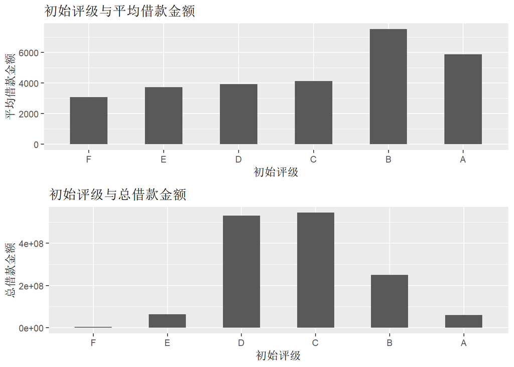

```r
p2_3.1 = ggplot(aes(x=初始评级,y=mean_jine),data=lc.by_pingji)+
  geom_bar(stat='summary',width=0.5) + ylab('平均借款金额') +
  ggtitle('初始评级与平均借款金额')
p2_3.2 = ggplot(aes(x=初始评级,y=sum_jine),data=lc.by_pingji)+
  geom_bar(stat='summary',width=0.5)+ylab('总借款金额') +
  ggtitle('初始评级与总借款金额')
grid.arrange(p2_3.1,p2_3.2,ncol=1)
```

结论：平均借款金融由大到小顺序是B,A,C,D,E,F，总借款金额顺序是C,D,B,E,A,F，因为 单变量分析时D,C评级人数最多

4.4.1 借款类型和借款利率的关系

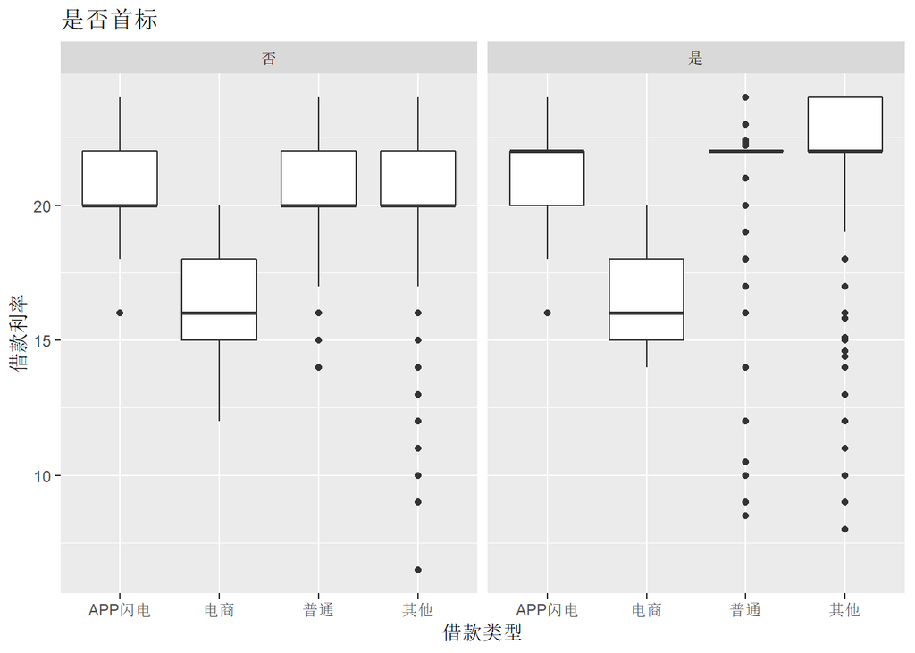

```r
ggplot(aes(x=借款类型,y=借款利率),data=lc) +
  geom_boxplot() + facet_wrap(~是否首标) + ggtitle('是否首标')
```

结论：不论是否首标，电商的借款利率都比较低

4.5 借款金额与借款利率之间的关系

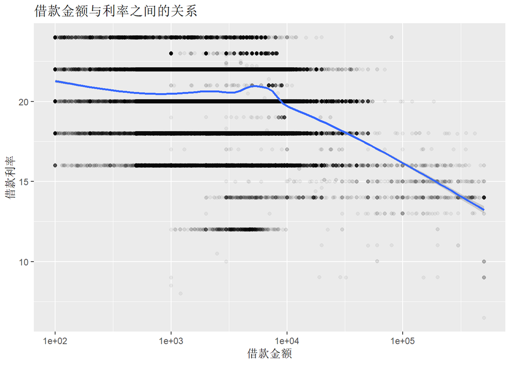

```r
ggplot(aes(x=借款金额,y=借款利率), data=lc) +
  geom_point(position='jitter',alpha=1/20) +
  scale_x_log10() +
  ggtitle('借款金额与利率之间的关系') +
  geom_smooth()
```

从图上可知：随着借款金额的增多，利率呈现的趋势是下降的

4.6 用户群体双变量分析

```
## No summary function supplied, defaulting to `mean_se()
## No summary function supplied, defaulting to `mean_se()
## No summary function supplied, defaulting to `mean_se()
```

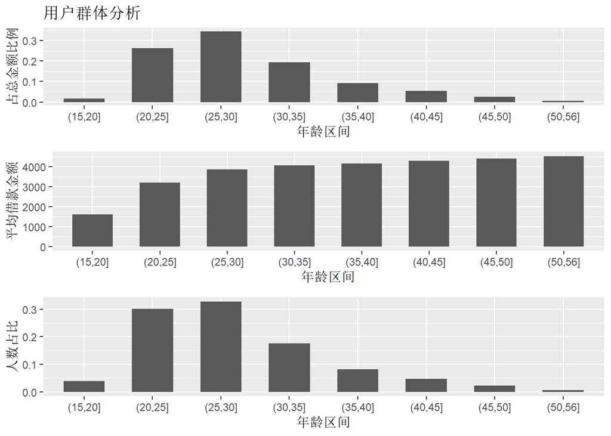

```r
total_jiekuan <- sum(within10000$借款金额)
len_w1 = length(within10000$借款金额)
age_qujian_group <- group_by(within10000,年龄区间)
w1.by_age_qujian <- summarise(age_qujian_group,
            total_percent = sum(as.numeric(借款金额))/total_jiekuan,
            mean_jiekuan = mean(as.numeric(借款金额)),
            n = n()/len_w1)
p4_6.1 = ggplot(aes(x=年龄区间,y=total_percent),data=w1.by_age_qujian) +
  geom_bar(stat='summary',width=0.6) +
  labs(y='占总金额比例',title='用户群体分析')
p4_6.2 = ggplot(aes(x=年龄区间,y=mean_jiekuan),data=w1.by_age_qujian) +
  geom_bar(stat='summary',width=0.6) + ylab('平均借款金额')
p4_6.3 = ggplot(aes(x=年龄区间,y=n),data=w1.by_age_qujian) +
  geom_bar(stat='summary',width=0.6) + ylab('人数占比')
grid.arrange(p4_6.1,p4_6.2,p4_6.3)
```

5. 多变量分析

5.1.1 年龄，性别和借款金额之间的关系

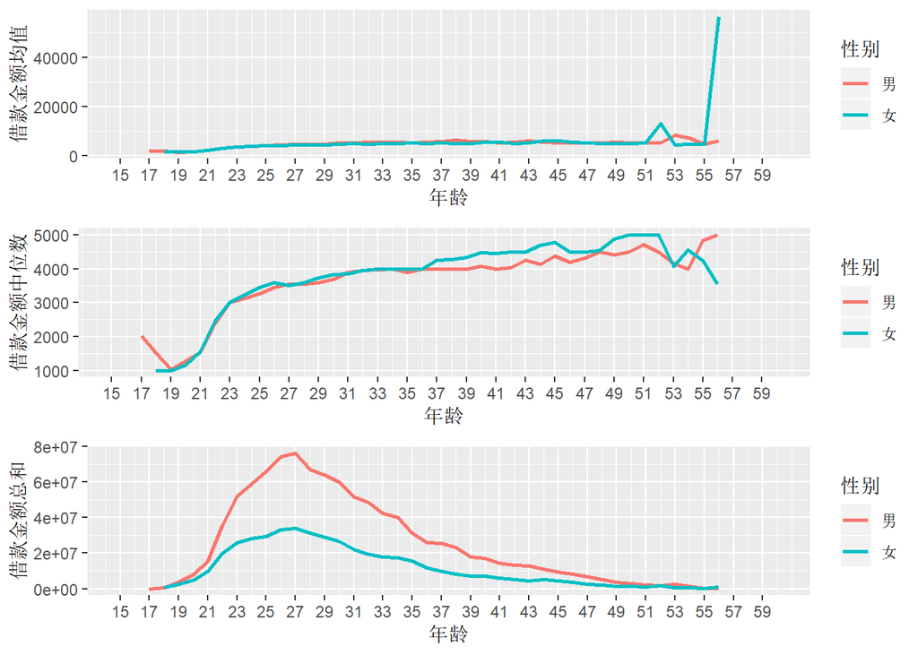

```r
p3_1.1 <- ggplot(aes(x=年龄,y=借款金额),data=lc) +
  geom_line(aes(color=性别),stat='summary',fun.y=mean,size=1) +
  scale_x_continuous(limits=c(15,60),breaks=seq(15,60,2)) +
  labs(y='借款金额均值')
p3_1.2 <- ggplot(aes(x=年龄,y=借款金额),data=lc) +
  geom_line(aes(color=性别),stat='summary',fun.y=median,size=1) +
  scale_x_continuous(limits=c(15,60),breaks=seq(15,60,2)) +
  labs(y='借款金额中位数')
p3_1.3 <- ggplot(aes(x=年龄,y=借款金额),data=lc) +
  geom_line(aes(color=性别),stat='summary',fun.y=sum,size=1) +
  scale_x_continuous(limits=c(15,60),breaks=seq(15,60,2)) +
  labs(y='借款金额总和')
grid.arrange(p3_1.1,p3_1.2,p3_1.3)
```

结论: 从借款金额平均值上来看，男女平均借款金额相差不大，但55岁以后女性平均借款金 额要比男姓大很多，根据前面的分析应该是个别借款金额比较大的极值影响；  
从借款金额中位树数上来看，男女之间差别也不是很大，但总体上随着年龄增长借款 金额都有所增长；  
但从借款金额总和上来看男女差异比较大大，男姓借钱总金额比女性更多一些，但借 钱总金额的趋势基本相同，都是先增长后降低，而且在20-40之间借钱金额比较多。

5.2.1 不同年龄的用户与借款类型情况的分析

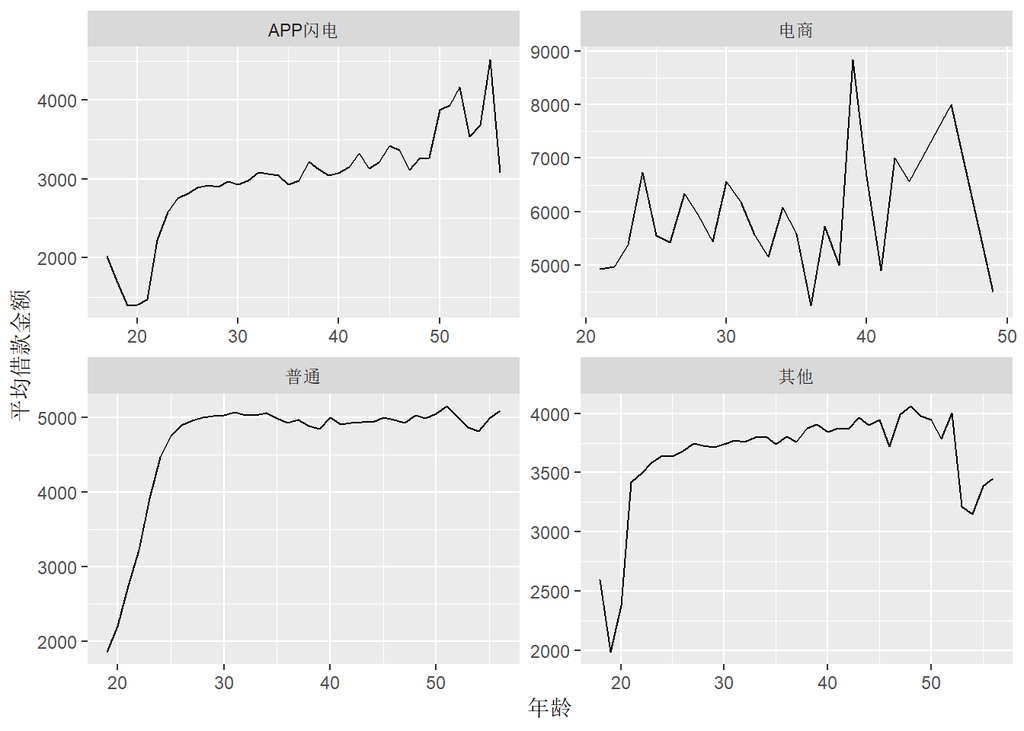

```r
ggplot(aes(x=年龄,y=借款金额),data=within10000) +
  geom_line(stat='summary',fun.y=mean)+
  facet_wrap(~借款类型,scale='free') + ylab('平均借款金额')
```

结论：不同类型借款类型的平均借款金额是不同的，电商整体的平均借款金额更高一些， 而APP闪电贷一般都比较偏低。

5.3.1 不同年龄的用户与认证分数之间的关系

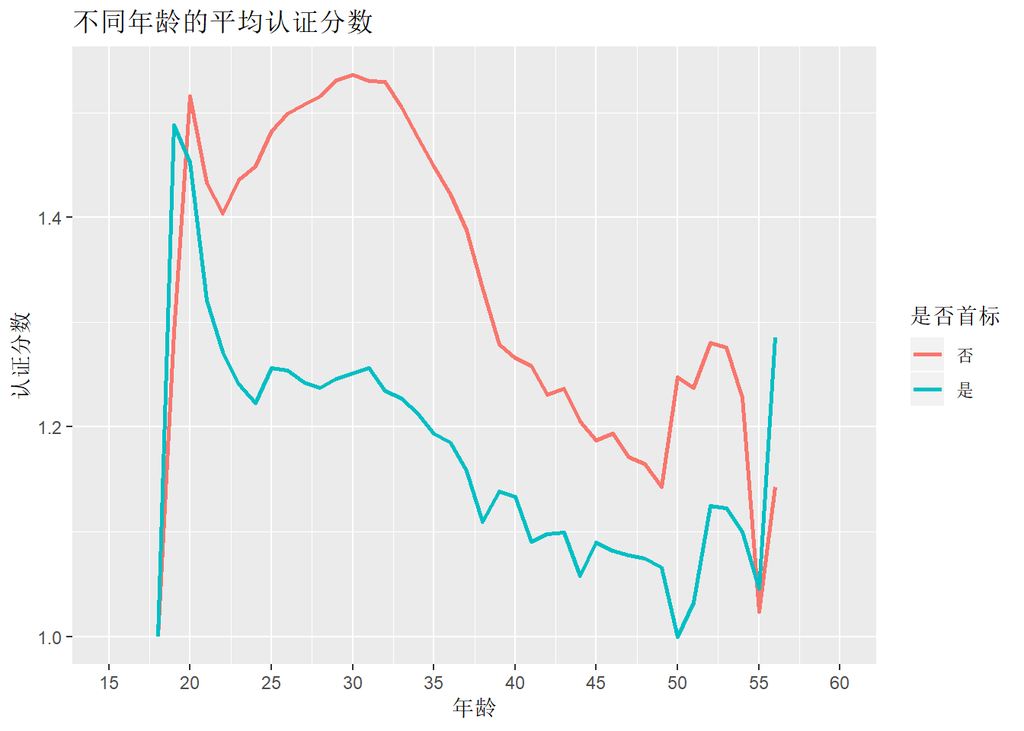

```r
ggplot(aes(x=年龄,y=认证分数),data=subset(lc,认证分数>0))+
  geom_line(aes(color=是否首标),size=1,stat='summary',fun.y=mean)+
  scale_x_continuous(limits=c(15,60),breaks=seq(15,60,5))+
  ggtitle('不同年龄的平均认证分数')
```

结论：在20-50岁之间的年龄段，首标的认证人数都低于非首标的认证分数，说明用户为 了增加借款金额多增加额外的认证

5.4.1 借款金额、年龄区间与初始评级之间的关系

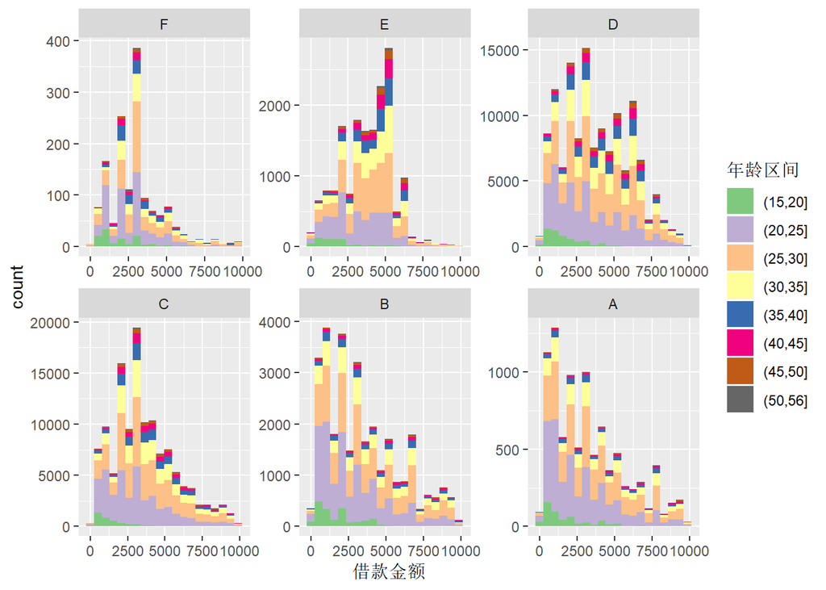

```r
ggplot(aes(x=借款金额,fill=年龄区间),data=within10000) +
  geom_histogram(bins = 20,position =position_stack(reverse=TRUE)) +
  facet_wrap(~初始评级,ncol=3,scales='free') +
  scale_fill_brewer(type='qual')
```

结论：不同初始评分级别的借款金额有很大的不同

5.5.1借款金额、借款利率与初始评级的关系

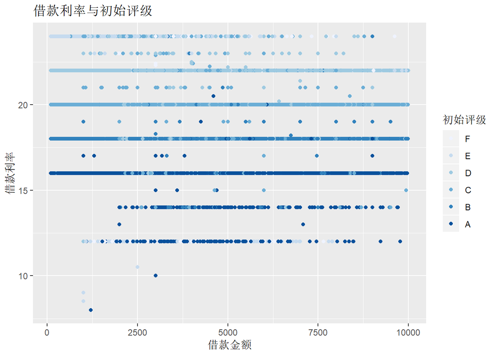

```r
ggplot(aes(x=借款金额,y=借款利率,color=初始评级),data=within10000)+
  geom_point()+
  scale_color_brewer(type='seq') +
  ggtitle('借款利率与初始评级')
```

结论：从整体上来看初始评分越高，借款利率越低。

5.6.1 借款金额、借款利率和认证分数之间的关系

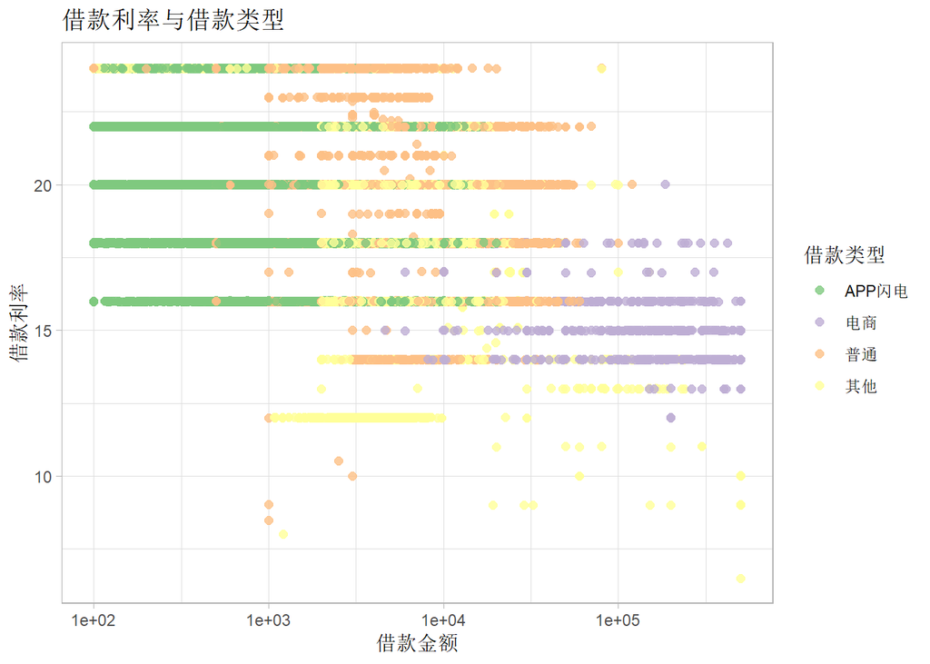

```r
ggplot(aes(x=借款金额,y=借款利率),data=lc)+
  geom_point(aes(color=借款类型),alpha=0.8,position='jitter',size=2)+
  scale_color_brewer(type='qual') + scale_x_log10() +
  ggtitle('借款利率与借款类型') +
  theme_light()
```

结论：APP闪电贷利率很高,但借款金额稍小。电商类利率较低，但借款金额都比较大。

5.7.1 借款金额、借款利率与借款周期之间的关系

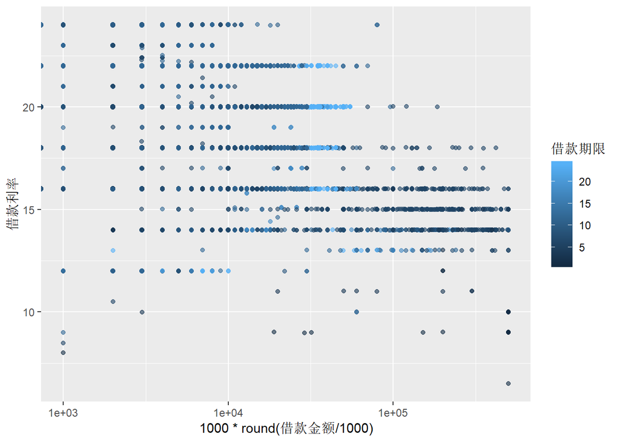

```r
ggplot(aes(x=1000*round(借款金额/1000),y=借款利率,color=借款期限),data=lc) +
  geom_point(alpha=0.6,position='jitter') + scale_x_log10()
```

5.8 借款类型、初始评级、借款利率之间的关系

```r
jklx_jkll <- subset(lc,select=c(借款类型,借款利率))
by(jklx_jkll$借款利率,jklx_jkll$借款类型,mean)
```

```
## jklx_jkll$借款类型: APP闪电
## [1] 20.32754
## --------------------------------------------------------
## jklx_jkll$借款类型: 电商
## [1] 16.11787
## --------------------------------------------------------
## jklx_jkll$借款类型: 普通
## [1] 20.98002
## --------------------------------------------------------
## jklx_jkll$借款类型: 其他
## [1] 20.50668
```

```
## No summary function supplied, defaulting to `mean_se()
## No summary function supplied, defaulting to `mean_se()
## No summary function supplied, defaulting to `mean_se()
## No summary function supplied, defaulting to `mean_se()
```

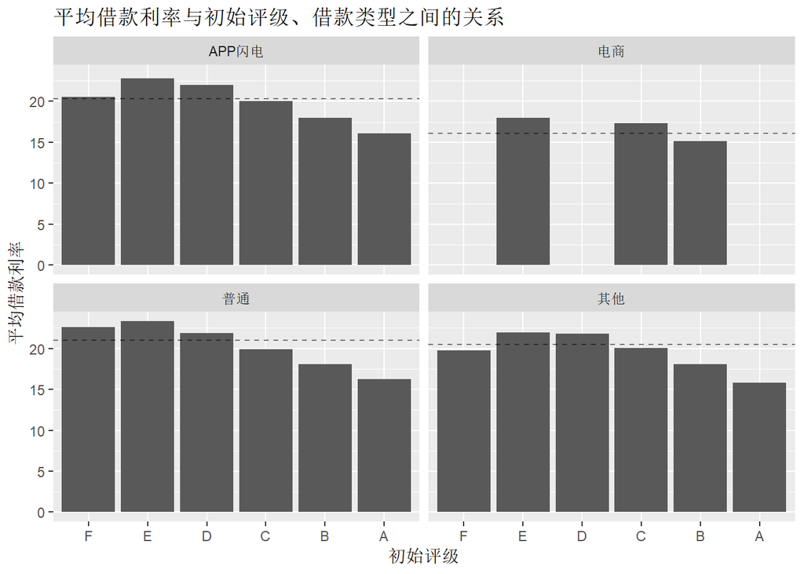

```r
mean_lxll <- data.frame(借款类型 = c('APP闪电','电商','普通','其他'),
                            借款利率 = c(20.33, 16.12, 20.98, 20.50))

age_qujian_rzfs_group <- group_by(lc,初始评级,借款类型)
w1.by_age_qujian_rzqs <- summarise(age_qujian_rzfs_group,
                                   mean_jkll = mean(as.numeric(借款利率)))
ggplot(aes(x=初始评级,y=mean_jkll),data=w1.by_age_qujian_rzqs) +
  geom_bar(stat='summary')+
  geom_hline(aes(yintercept=借款利率),data=mean_lxll,alpha=0.5, linetype=2) +
  facet_wrap(~借款类型) +
  labs(y='平均借款利率',title='平均借款利率与初始评级、借款类型之间的关系')
```

5.8 多变量分析的结论  
1.借款利率随着初始评级的升高而降低  
2.借款利率随着借款期限的增长而增加  
3.借款金额越大借款利率越低  
4.借款利率和借款类型相关。APP闪电借款利率较大，周期也较短而且借款期限也较  
短。电商类借款利率相对较低，而且借款周期较长可借金额也比较大。

6.利率预测

```r
m1 <- lm(I(借款利率)~I(借款金额),data=lc)
m2 <- update(m1, ~.+初始评级)
m3 <- update(m2,~.+认证分数)
m4 <- update(m3,~.+借款类型)
m5 <- update(m4,~.+借款期限)
mtable(m1,m2,m3,m4,m5)
```

```
##
## Calls:
## m1: lm(formula = I(借款利率) ~ I(借款金额), data = lc)
## m2: lm(formula = I(借款利率) ~ I(借款金额) + 初始评级, data = lc)
## m3: lm(formula = I(借款利率) ~ I(借款金额) + 初始评级 + 认证分数,
##     data = lc)
## m4: lm(formula = I(借款利率) ~ I(借款金额) + 初始评级 + 认证分数 +
##     借款类型, data = lc)
## m5: lm(formula = I(借款利率) ~ I(借款金额) + 初始评级 + 认证分数 +
##     借款类型 + 借款期限, data = lc)
##
## ==========================================================================================================
##                                 m1              m2              m3              m4              m5
## ----------------------------------------------------------------------------------------------------------
##   (Intercept)                  20.705***       20.087***       20.142***       20.121***       19.768***
##                                (0.003)         (0.004)         (0.004)         (0.005)         (0.007)
##   I(借款金额)                  -0.000***       -0.000***       -0.000***       -0.000***       -0.000***
##                                (0.000)         (0.000)         (0.000)         (0.000)         (0.000)
##   初始评级: .L                                 -5.087***       -5.078***       -5.076***       -5.012***
##                                                (0.014)         (0.014)         (0.014)         (0.014)
##   初始评级: .Q                                 -2.322***       -2.312***       -2.324***       -2.302***
##                                                (0.013)         (0.013)         (0.013)         (0.013)
##   初始评级: .C                                  1.115***        1.109***        1.094***        1.043***
##                                                (0.010)         (0.010)         (0.010)         (0.010)
##   初始评级: ^4                                 -0.280***       -0.276***       -0.280***       -0.283***
##                                                (0.006)         (0.006)         (0.006)         (0.006)
##   初始评级: ^5                                 -0.009*          0.002           0.006           0.041***
##                                                (0.004)         (0.004)         (0.004)         (0.004)
##   认证分数                                                     -0.067***       -0.054***       -0.053***
##                                                                (0.002)         (0.002)         (0.002)
##   借款类型: 电商/APP闪电                                                       -1.872***       -1.689***
##                                                                                (0.031)         (0.031)
##   借款类型: 普通/APP闪电                                                        0.030***        0.026***
##                                                                                (0.004)         (0.004)
##   借款类型: 其他/APP闪电                                                       -0.069***       -0.065***
##                                                                                (0.004)         (0.004)
##   借款期限                                                                                      0.035***
##                                                                                                (0.001)
## ----------------------------------------------------------------------------------------------------------
##   R-squared                     0.022           0.778           0.779           0.782           0.785
##   adj. R-squared                0.022           0.778           0.779           0.782           0.785
##   sigma                         1.753           0.835           0.833           0.827           0.823
##   F                          7382.178      192164.030      165676.949      117978.167      108790.916
##   p                             0.000           0.000           0.000           0.000           0.000
##   Log-likelihood          -650589.502     -406814.070     -406066.427     -403867.672     -402034.898
##   Deviance                1009442.254      228884.966      227845.649      224816.373      222322.116
##   AIC                     1301185.004      813644.139      812150.854      807759.344      804095.796
##   BIC                     1301217.112      813729.759      812247.176      807887.774      804234.928
##   N                        328553          328553          328553          328553          328553
## ==========================================================================================================
```

6.1 预测

```r
test <- data.frame(借款金额=10000,初始评级='B', 认证分数= 3,
                       借款类型='电商', 借款期限 = 12)

modelEstimate = predict(m5,newdata=test,
                        interval = "prediction",level=0.95)
modelEstimate
```

```
##        fit     lwr      upr
## 1 16.32252 14.7091 17.93594
```

7. 最终成图和汇总 绘图一：按年、月、日分析借款总体情况

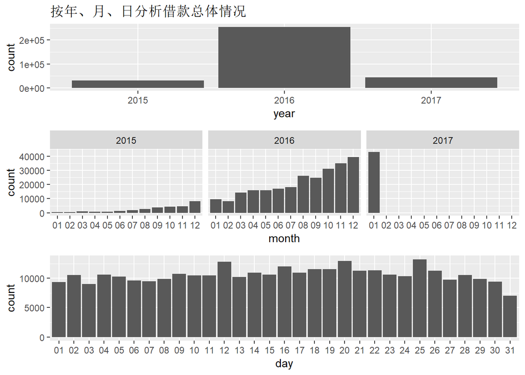

```r
year_lc <- ggplot(aes(x=year), data=lc) + geom_bar() +
  ggtitle('按年、月、日分析借款总体情况')

month_lc <- ggplot(aes(x=month), data=lc) + geom_bar() + facet_wrap(~year)

day_lc <- ggplot(aes(x=day), data=lc) + geom_bar()

grid.arrange(year_lc,month_lc,day_lc,ncol=1)
```

结论：上图反应了拍拍贷从2015年到2017年的总体业务情况，从图中可以看到从2015年到 2016年借款数量增长迅速。从月份图上可以看到，2017年虽然只有1月份的数据，但仍然要 比2016年最好的月份的数据还要好，因此有理由相信2017年以后的数据会更好。整体上看， 拍拍贷的业务一直在稳定的增长，而且按天来看，基本每天的业务都很均衡。

绘图二：用户群体的分析

```
## No summary function supplied, defaulting to `mean_se()
## No summary function supplied, defaulting to `mean_se()
## No summary function supplied, defaulting to `mean_se()
```

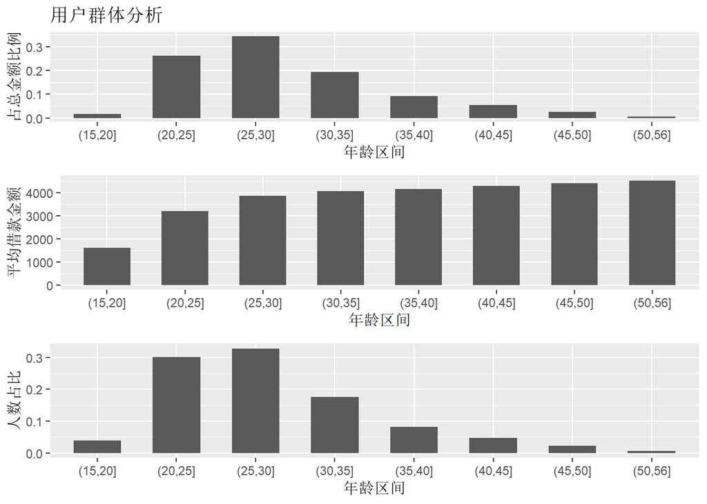

```r
total_jiekuan <- sum(within10000$借款金额)
len_w1 = length(within10000$借款金额)
age_qujian_group <- group_by(within10000,年龄区间)
w1.by_age_qujian <- summarise(age_qujian_group,
            total_percent = sum(as.numeric(借款金额))/total_jiekuan,
            mean_jiekuan = mean(as.numeric(借款金额)),
            n = n()/len_w1)
p4_6.1 = ggplot(aes(x=年龄区间,y=total_percent),data=w1.by_age_qujian) +
  geom_bar(stat='summary',width=0.6) +
  labs(y='占总金额比例',title='用户群体分析')
p4_6.2 = ggplot(aes(x=年龄区间,y=mean_jiekuan),data=w1.by_age_qujian) +
  geom_bar(stat='summary',width=0.6) + ylab('平均借款金额')
p4_6.3 = ggplot(aes(x=年龄区间,y=n),data=w1.by_age_qujian) +
  geom_bar(stat='summary',width=0.6) + ylab('人数占比')
grid.arrange(p4_6.1,p4_6.2,p4_6.3)
```

绘图三：借款金额、借款利率、认证分数、初始评级、借款类型之间的关系

```
## No summary function supplied, defaulting to `mean_se()
## No summary function supplied, defaulting to `mean_se()
## No summary function supplied, defaulting to `mean_se()
## No summary function supplied, defaulting to `mean_se()
```

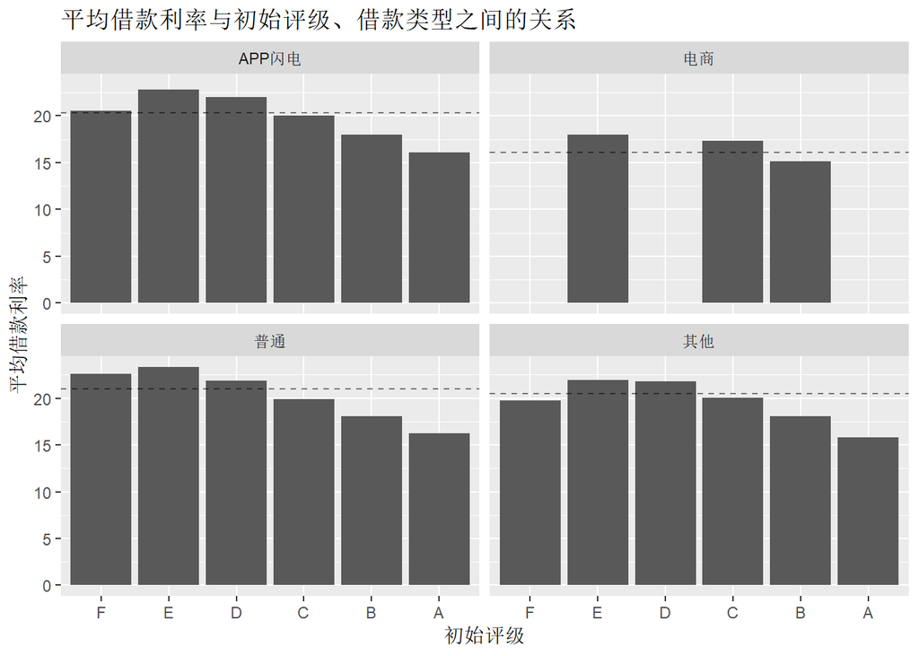

```r
mean_lxll <- data.frame(借款类型 = c('APP闪电','电商','普通','其他'),
                            借款利率 = c(20.33, 16.12, 20.98, 20.50))

age_qujian_rzfs_group <- group_by(lc,初始评级,借款类型)
w1.by_age_qujian_rzqs <- summarise(age_qujian_rzfs_group,
                                   mean_jkll = mean(as.numeric(借款利率)))
ggplot(aes(x=初始评级,y=mean_jkll),data=w1.by_age_qujian_rzqs) +
  geom_bar(stat='summary')+
  geom_hline(aes(yintercept=借款利率),data=mean_lxll,alpha=0.5, linetype=2) +
  facet_wrap(~借款类型) +
  labs(y='平均借款利率',title='平均借款利率与初始评级、借款类型之间的关系')
```

8. 反思

8.1 整个分析的思路，是从单变量到双边在到多变量进行分析，在逐步深入的过程中 发现问题解决问题，其中由于基础知识掌握不是很牢固，因此遇到了不少麻烦，不过好在 有论坛可以提问，获得了不少帮助。

8.2 在分析的过程中，发现有部分借款借款金额非常大，例如95%的人借款金额都不超过 1万，但是有部分人的借款金额达到了50万，这部分较大的借款金额可能是录入错误，也可 能是真实数据。在未说明情况下可以有不同的理解，因此借款均值就会有差异。实际项目分 析时，可以把该类数据单独筛选并进行分析，或许能发现新的东西。

8.3 在分析的过程中，分析之前可能直观为认为借款金额与利率之间有很强烈的关系，实 际结果却并不是。而借款类型，初始评级和认证分数和借款利率关系比较大，这与分析之前 的猜想是有出入的。

8.4 在逐步深入分析的过程中，每多一次分析，都能发现新的不一样的东西。在以后的工 作中，应该从更多的方面去尝试，站在不同的角度去分析，并且在每次分析的过程中不断改 进，这样就能逐步提高分析内容和报告质量。